# Communicating Data Findings

# by Preethi Barugur Nagaraj

# Dataset Overview

Increasing urbanization and road congestion are pushing commuters toward alternative modes of transportation for short and medium distance journeys.

FordGoBike System is one of the businesses that have emerged with solutions aiming to capitalize on the LSV business opportunity.

This FordGoBikeSystem dataset includes information about individual rides made in a bike-sharing system covering the greater San Francisco Bay area.

Through this data analysis, the goal is to draw insights from the sharing-mobility usage data for future strategic decision making.

# Investigation Overview

**As part of my exploration, I set out to find answers to some of the questions that could help business in making strategic decisions aimed towards increasing profitability in the future,**

**1) Which of our user types use our bikesharing system the most?** This coud help the business identify their most profitable target customer segment and the least profitable target customer segment. By understanding this, the business will likely be able to make decision on how to increase the usage of their bikesharing system amongst the least used customer types.  
**2) Which rental access methods do our customers use the most?** This could help business identify, where they are likely to make most sales, through app or dipper. This could potentially help identify what portion of their revenue from each rental access method and what amount of the revenue is lost as commission to external third party applications.  
**3) Which is the bikeshare systems high demand station?** This could help the business understand how they can better cater to the needs of their high volume customers in this station.  
**4) Which is the bikeshare systems low demand station?** This could help understand which stations are least profitable to business and determine ways on how to make it more profitable.  
In this slide deck, My investigation is aimed at drawing relationships between differnt variables that potentially analyze the factors that correspond to the profitability of the *high demand station.*

# Visualizations - Analyzing the factors that has business implications on the High Demand Station

# Variation in usage between Customers and Subscribers of @High Demand Station

Through our analysis we can see that the trip duration is much narrower for the Subscribers while it is comparitively wide for the Customers/Casual Riders. This makes sense as from our previous explorations we noticed that the end users of this fordgobike sharing system seem to mostly be office going, school going and college going kind of people who are more prone to having a consistent pattern of usage duration, while for a casual rider it tends to vary highly and thus attributes to a comparitively wider range here.

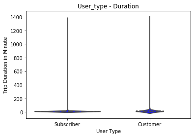

```python
sb.violinplot(data=df_new, x='user_type', y='duration_min', color='Blue', inner='quartile');
plt.xlabel('User Type');
plt.title('User_type - Duration')
plt.ylabel('Trip Duration in Minute');
```

# Trip frequency by Month @High Demand Station

The FordGoBike System at the high demand station has a majority of Subscriber users compared to casual riders. The months that seem to be facing the highest demand are March, April and October. But what is interesting to notice here is that the bikes are least used in the month of December, this I believe can be attributed to the fact that December is the time when most Office, College goers are on vacation and have least use of every riding, hence very low demand in this month.

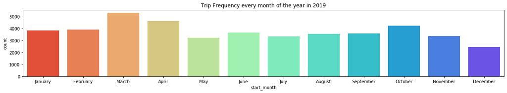

```python
months = ['January', 'February', 'March', 'April', 'May', 'June', 'July', 'August', 'September', 'October', 'November', 'December']
plt.figure(figsize = [20, 20]);
plt.subplot(6, 1, 1);
plt.title('Trip Frequency every month of the year in 2019')
sb.countplot(data = df_new, x = 'start_month', order = months, palette = 'rainbow_r');
```

# Trip Frequency by Day of the Week @High Demand Station

The trip frequency at the high demand station is high during the weekdays and less during the weekends. This provides insight into the activity pattern of fordgobike's target customers in this area. It is higly likely that they are office goers or college goers, who regularly commute to work or school during the weekdays and travel very less on the weekends.

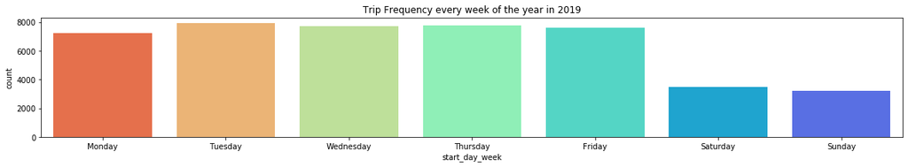

```python
#Visualizing the trip frequency by day of the week

weekday = ['Monday','Tuesday','Wednesday','Thursday','Friday','Saturday','Sunday']
plt.figure(figsize = [20, 20]);
plt.subplot(6, 1, 1);
plt.title('Trip Frequency every week of the year in 2019')
sb.countplot(data = df_new, x = 'start_day_week', order = weekday, palette = 'rainbow_r');
```

# Trip Frequency by Hour of the day @High Demand Station

The trip frequency at the high demand station is high in the mornings between 8am-9am and also in the evening between 5pm-6pm.

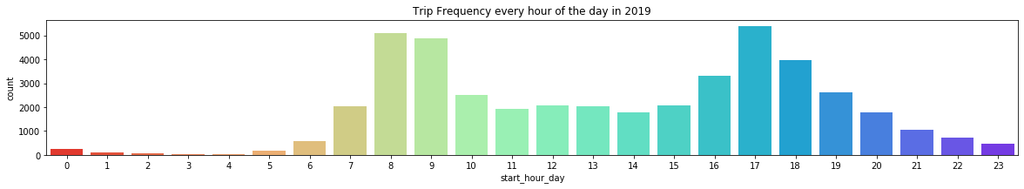

```python
#Visualizing the trip frequency by hour of the day

plt.figure(figsize = [20, 20]);
plt.subplot(6, 1, 1);
plt.title('Trip Frequency every hour of the day in 2019')
sb.countplot(data = df_new, x = 'start_hour_day', palette = 'rainbow_r');
```

# Usage of Bike by Hour @ High Demand Station

Except on the weekends, the FordGoBike system at the high demand station faces heavy demand between 8am-9am in the mornings and approximately 4.30pm to 5.30pm in the evenings on weekdays

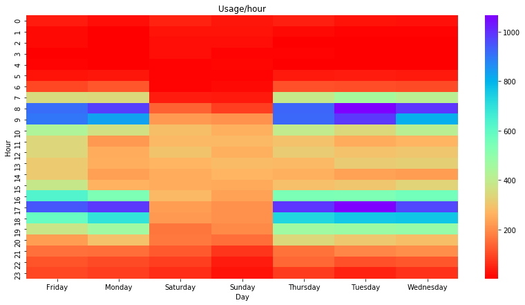

```python
hour_count=df_new.groupby(['start_day_week','start_hour_day']).size()
hour_count = hour_count.reset_index(name = 'count')
hour_count = hour_count.pivot(index = 'start_hour_day', columns = 'start_day_week', values = 'count')
plt.figure(figsize=(14, 7))
b=sb.heatmap(hour_count,square=False,cmap='rainbow_r')
b.set_title('Usage/hour')
b.set_ylabel('Hour')
b.set_xlabel('Day');
```

# Usage of Bike by Hour and Day of the Week @High Demand Station

The Graph below shows the multivariate relationship between the user_types and the hourly usage of the bikes on different days of the week. As we can see, the hourly usage is high in the mornings between 8am-9am and in the evenings between 5pm-6pm also, the demand is high on the weekdays more than the weekends, which makes sense as our target population is mostly adults in the middle 25s-30s who are office goers or college goers given SFO Bay area is highly populated with big tech.

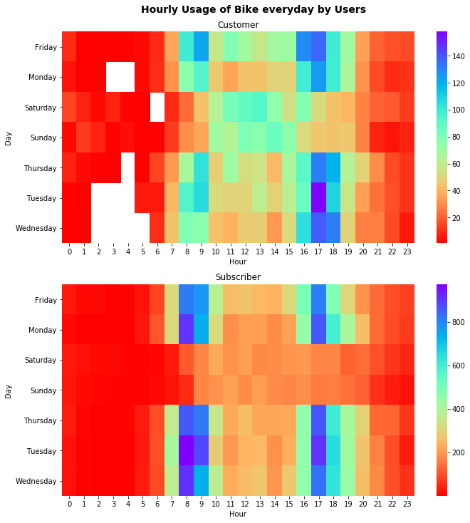

```python
weekday = ['Sunday','Monday','Tuesday','Wednesday','Thursday','Friday','Saturday']

plt.figure(figsize=[10, 10]);

plt.subplot(2, 1, 1)
customers = df_new.query('user_type == "Customer"')
cus_count = customers.groupby(['start_day_week', 'start_hour_day']).size()
cus_count = cus_count.reset_index(name='count')
cus_count = cus_count.pivot(index='start_day_week', columns='start_hour_day', values='count')
sb.heatmap(cus_count, cmap='rainbow_r');
plt.title('Customer');
plt.xlabel('Hour');
plt.ylabel('Day');
plt.tight_layout();

plt.subplot(2, 1, 2)
subscribers = df_new.query('user_type == "Subscriber"')
sub_count = subscribers.groupby(['start_day_week', 'start_hour_day']).size()
sub_count = sub_count.reset_index(name='count')
sub_count = sub_count.pivot(index='start_day_week', columns='start_hour_day', values='count')
sb.heatmap(sub_count, cmap='rainbow_r');
plt.title('Subscriber');
plt.xlabel('Hour');
plt.ylabel('Day');
plt.tight_layout();
plt.suptitle('Hourly Usage of Bike everyday by Users', fontsize=14, fontweight='semibold', y=1.015);
```

# Summary

Some Key Insights:

1) The Ford GoBike tagline is “A fun and affordable way to get around” with pictures of young adults. And true to its tagline, fordgobike has attracted a lucrative target customer base in young-middle aged adults who use bikes for regular office commute.Overall, FordGoBike has carved for itself a profitable & ever blooming business.

2) There are 2M riders in the year 2019 alone in the San Francisco Bay Area, which can be attributed to the heavy tech, health conscious population in this area along with the nice warm weather that makes riding a more favorable travel option in this city.

3) The Station Market St 10th St is the station with the highest demand, this can be attributed to the growing number of tech companies in that area.

4) The majority of the users at this station are Subscribers, because they use fordgobikes for everyday commutes to work.

5) It was interesting to notice how the demand falls low in the Month of December,which can be attributed to vacation times and hence the business could think about ways to increase usage in this month by offering discounts or promotions that attract our users to use bikes during this time as well.

These are some of my key insights from analysing the data.